# Final Project

Lucas Fox, Nathalie Kirsch, Vanaaisha Pamnani, Cuong Pham Vu

5/6/2022

### PPOL 670 | Final Project

This assignment is stored on the following [Github repository](https://github.com/nakirsch/PPOL670_FinalProject).

Our data visualizations and predictive modeling can provide policymakers a better understanding of the types, frequency, and patterns of crimes reported in DC. More importantly, it provides an in-depth look at what factors contribute to crime in DC both pre and post pandemic, informing policymakers on potential ways to address crimes in DC.

```r
library(tidyverse)
library(tidymodels)
library(ggplot2)
library(patchwork)
library(sf)
library(janitor)
library(lubridate)
library(grid)
library(igraph)
library(ggraph)
library(gifski)
library(gganimate)

theme_set(theme_minimal())
```

### Creating Datasets on Crime Incidents

The geojson files come from Open Data DC, the District of Columbia’s open source database. From this database, we gathered DC crime data from 2010 to 2022 which includes crimes reported in different areas of DC with information such as report date, type of offense, location of crime incident, and time of event. From this data, we created two datasets: crime_data_total, which includes DC crime incidents reported from 2019 to 2022, and crime_data_2010s, which includes DC crime incidents reported from 2010 to 2019.

```r
#Load in data
crime_data22 <- st_read("data/Crime_Incidents_in_2022.geojson") %>%
  clean_names()
crime_data21 <- st_read("data/Crime_Incidents_in_2021.geojson") %>%
  clean_names()
crime_data20 <- st_read("data/Crime_Incidents_in_2020.geojson") %>%
  clean_names()
crime_data19 <- st_read("data/Crime_Incidents_in_2019.geojson") %>%
  clean_names()
crime_data18 <- st_read("data/Crime_Incidents_in_2018.geojson") %>%
  clean_names()
crime_data17 <- st_read("data/Crime_Incidents_in_2017.geojson") %>%
  clean_names()
crime_data16 <- st_read("data/Crime_Incidents_in_2016.geojson") %>%
  clean_names()
crime_data15 <- st_read("data/Crime_Incidents_in_2015.geojson") %>%
  clean_names()
crime_data14 <- st_read("data/Crime_Incidents_in_2014.geojson") %>%
  clean_names()
crime_data13 <- st_read("data/Crime_Incidents_in_2013.geojson") %>%
  clean_names()
crime_data12 <- st_read("data/Crime_Incidents_in_2012.geojson") %>%
  clean_names()
crime_data11 <- st_read("data/Crime_Incidents_in_2011.geojson") %>%
  clean_names()
crime_data10 <- st_read("data/Crime_Incidents_in_2010.geojson") %>%
  clean_names()
#Combine data
crime_data_total <- rbind(crime_data22, crime_data21)
crime_data_total <- rbind(crime_data_total, crime_data20)
crime_data_total <- rbind(crime_data_total, crime_data19)

crime_data_2010s <- rbind(crime_data19, crime_data18)
crime_data_2010s <- rbind(crime_data_2010s, crime_data17)
crime_data_2010s <- rbind(crime_data_2010s, crime_data16)
crime_data_2010s <- rbind(crime_data_2010s, crime_data15)
crime_data_2010s <- rbind(crime_data_2010s, crime_data14)
crime_data_2010s <- rbind(crime_data_2010s, crime_data13)
crime_data_2010s <- rbind(crime_data_2010s, crime_data12)
crime_data_2010s <- rbind(crime_data_2010s, crime_data11)
crime_data_2010s <- rbind(crime_data_2010s, crime_data10)
```

### Converting Data and Creating Counts of the Number of Crimes

In order to analyze this data, we converted our datasets into four different datasets:

crime_data_total_2: We separated and converted the crime incident report date into a ‘Date’ classification using our “crime_data_total” dataset.

crime_data_2010s_2: We separated and converted the crime incident report date into a ‘Date’ classification using our “crime_data_2010s” dataset.

crime_count: We filtered, grouped, and summarized our “crime_data_total_2” dataset to create a dataset with the number of crimes reported in January, February, and March in the years 2019 to 2022.

crime_graph_data: We grouped and summarized our “crime_data_total_2” to create a dataset counting the number of crimes reported by date from 2019 to 2022.

```r
crime_data_total_2 <- crime_data_total %>%
  separate(
    col = report_dat,
    into = c("date", "time"),
    sep = " ",
    remove = FALSE
  ) %>%
  mutate(year = year(date),
         month = month(date),
         day = day(date),
         ymd = paste(year, month, day, sep = "-"),
         date2 = as.Date(ymd))

crime_count <- crime_data_total_2 %>%
  filter(month < 4,
         !is.na(ward))%>%
  group_by(ward, year) %>%
  summarize(count = n()) %>%
  st_drop_geometry()

crime_graph_data <- crime_data_total_2 %>%
  group_by(date2) %>%
  summarize(count = n()) %>%
  st_drop_geometry()

crime_data_2010s_2 <- crime_data_2010s %>%
  separate(
    col = report_dat,
    into = c("date", "time"),
    sep = " ",
    remove = FALSE
  ) %>%
  mutate(year = year(date),
         month = month(date))

crime_count_2010s <- crime_data_2010s_2 %>%
  filter(!is.na(ward))%>%
  group_by(ward, year) %>%
  summarize(count = n()) %>%
  st_drop_geometry()
```

### Exploratory Analysis of Crime in DC Between 2019 and 2022

The bar chart below visualizes number of crimes reported in each ward by type of offense in Washington, DC from 2019 to 2022. We also provide a map of DC’s 8 wards below for reference.

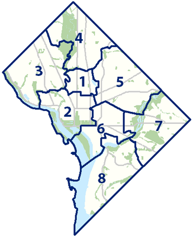

DC.gov: Wards of the District of Columbia

Based on the visualization below, arson, homicide, and sex abuse are the least commonly reported crimes, while theft is the most common. The ward with the highest overall crime counts is Ward 2, where Georgetown University is located.

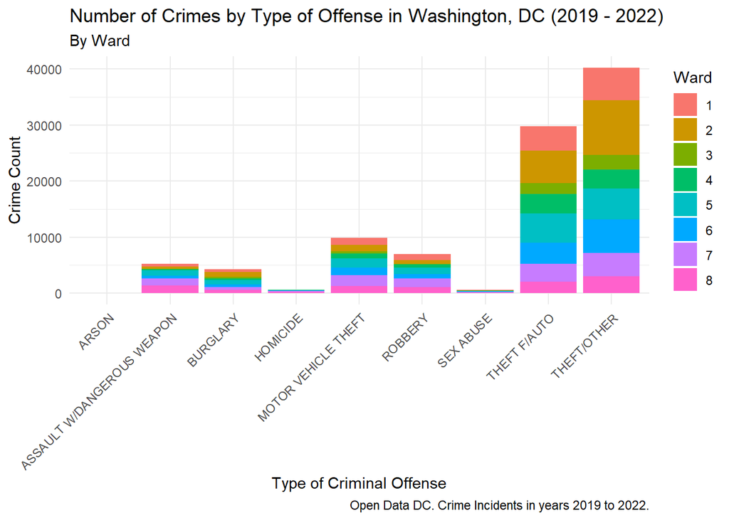

```r
#Type of Crime Committed by Crime Count
crime_data_total_2 %>%
  filter(!is.na(ward)) %>%
  ggplot(aes(offense, fill = ward)) +
  geom_bar() +
  labs(
    title = "Number of Crimes by Type of Offense in Washington, DC (2019 - 2022)",
    subtitle = "By Ward",
    x = "Type of Criminal Offense",
    y = "Crime Count",
    fill = "Ward",
    caption = "Open Data DC. Crime Incidents in years 2019 to 2022."
  ) +
  theme(axis.text.x=element_text(angle=45,hjust=1))
```

The bar chart below visualizes number of crimes reported in all of DC from 2019 to 2022 based on the shift time (Day, Evening, Midnight) the crime was reported. Based on the visualization, the evening shift has the most reported crimes and the midnight shift has the least.

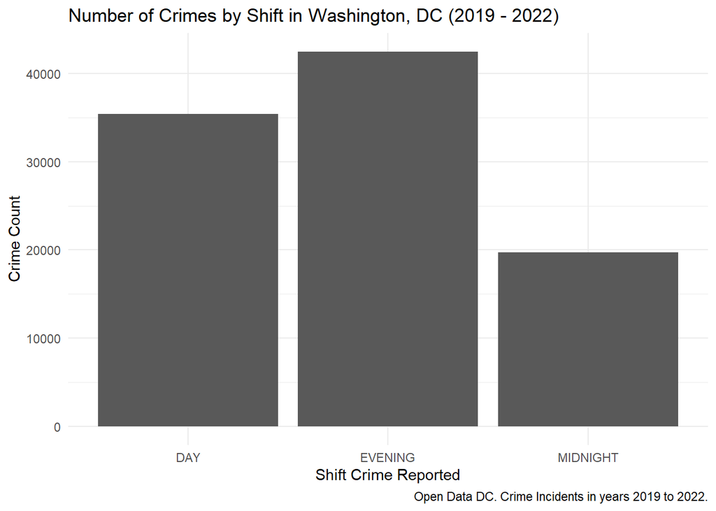

```r
# Shift Crime Report by Crime Count
crime_data_total_2 %>%
  filter(!is.na(ward)) %>%
  ggplot(aes(shift)) +
  geom_bar() +
  labs(
    title = "Number of Crimes by Shift in Washington, DC (2019 - 2022)",
    x = "Shift Crime Reported",
    y = "Crime Count",
    caption = "Open Data DC. Crime Incidents in years 2019 to 2022."
  )
```

The 4 bar charts below reflect the number of crimes in Washington, DC by ward for the months January to March in the years 2019, 2020, 2021, and 2022. Overall, crimes vastly decreased during the pandemic years (2021-2022) compared to pre-pandemic ones (2019-2020).

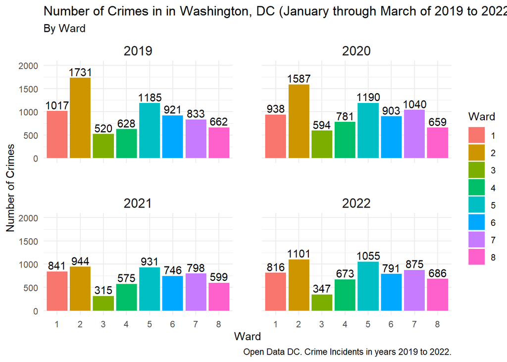

```r
#Number of crimes in January Through March
crime_count %>%
  ggplot(mapping = aes(x = ward, y = count, fill = ward, ymax = 2000)) +
  geom_col() +
  facet_wrap(~year) +
  geom_text(aes(label = count, vjust = -0.25)) +
  labs (
    title = "Number of Crimes in in Washington, DC (January through March of 2019 to 2022)",
    subtitle = "By Ward",
    x = "Ward",
    y = "Number of Crimes",
    caption = "Open Data DC. Crime Incidents in years 2019 to 2022."
  ) +
  scale_fill_discrete(name = "Ward") +
  theme(panel.spacing = unit(2, "lines"),
        strip.text = element_text(size = 13))
```

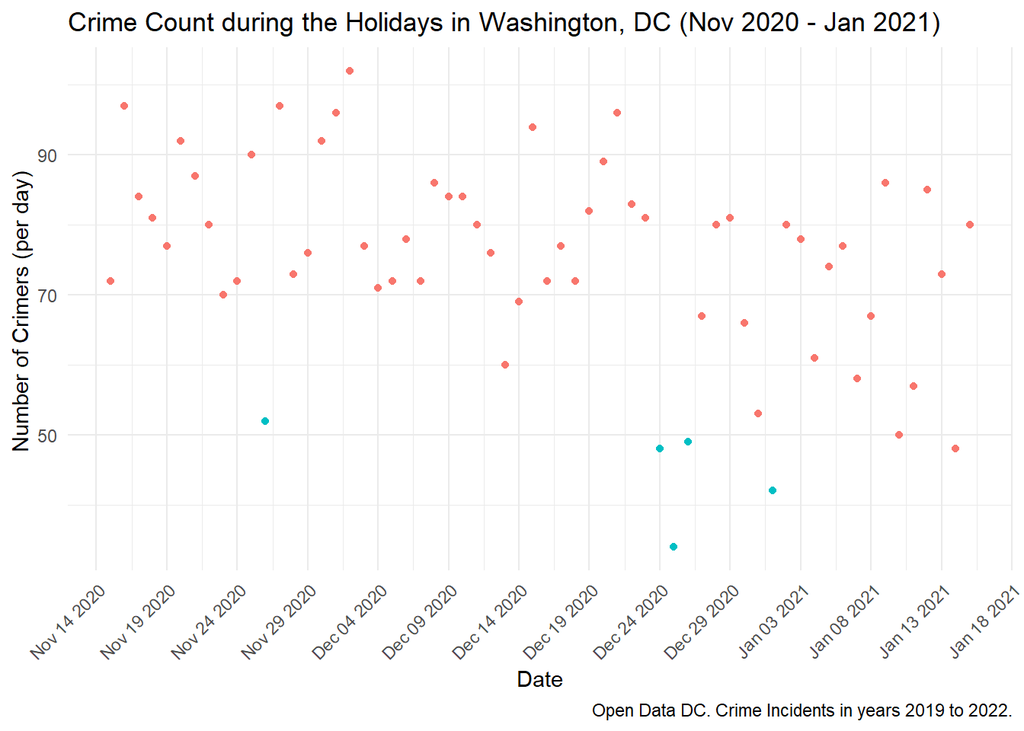

```r
#Crime Count during the Holidays (2020 - 2021)
crime_graph_data %>%
  filter("2020-11-14" < date2) %>%
  filter( date2 < "2021-01-16") %>%
  ggplot(aes(date2, count, label = date2, color = count < 53 & date2 < "2021-01-02")) +
  geom_point() +
  labs(
    x = "Date",
    y = "Number of Crimers (per day) ",
    title = "Crime Count during the Holidays in Washington, DC (Nov 2020 - Jan 2021)",
    caption = "Open Data DC. Crime Incidents in years 2019 to 2022."
  ) +
 scale_x_date(breaks = "5 days",
             date_labels = "%b %d %Y") +
  theme(legend.position="none",axis.text.x=element_text(angle=45,hjust=1))
```

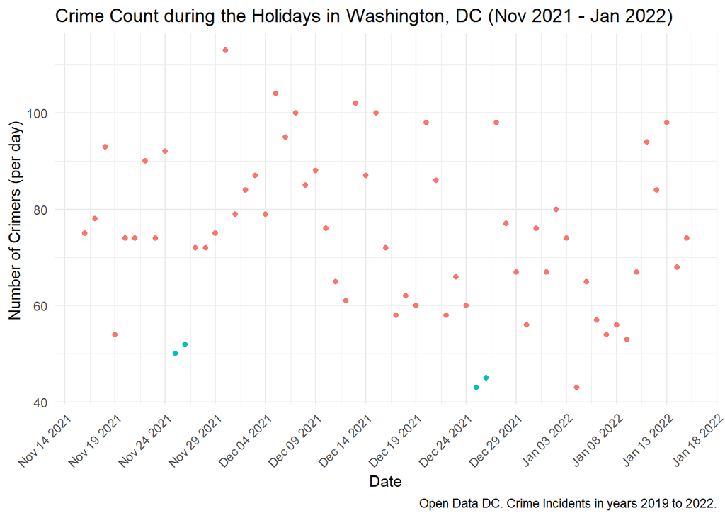

```r
#Crime Count during the Holidays (2021 - 2022)
crime_graph_data %>%
  filter("2021-11-15" < date2) %>%
  filter( date2 < "2022-01-16") %>%
  ggplot(aes(date2, count, label = date2, color = count < 53 & date2 < "2022-01-02")) +
  geom_point() +
  labs(
    x = "Date",
    y = "Number of Crimers (per day) ",
    title = "Crime Count during the Holidays in Washington, DC (Nov 2021 - Jan 2022)",
    caption = "Open Data DC. Crime Incidents in years 2019 to 2022."
  ) +
 scale_x_date(breaks = "5 days",
             date_labels = "%b %d %Y") +
    theme(legend.position="none",axis.text.x=element_text(angle=45,hjust=1))
```

### Exploratory Analysis of Crime in DC Between 2010 and 2019

The animated bar graph explores the number of crimes reported by ward from the years 2010 to 2019. Over the past decade, crime rates varied year by year. In 2016, mostly all of DC’s wards significantly increased in crimes reported compared to the other years. Additionally, Ward 2 was consistently the highest in crimes reported from 2010 to 2019.

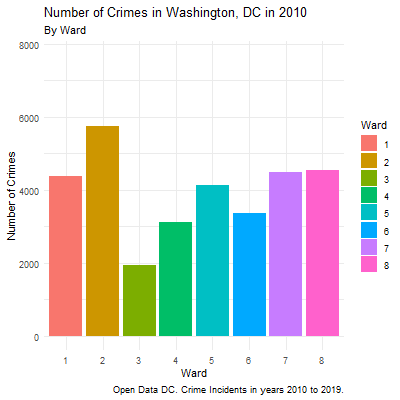

```r
#Animated plot for change in crime over time
crime_over_time <- crime_count_2010s %>%
  ggplot(mapping = aes(x = ward, y = count, fill = ward)) +
  geom_col() +
  labs (
    title = "Number of Crimes in Washington, DC in {frame_time}",
    subtitle = "By Ward",
    x = "Ward",
    y = "Number of Crimes",
    caption = "Open Data DC. Crime Incidents in years 2010 to 2019.",
  ) +
  scale_fill_discrete(name = "Ward") +
  transition_time(as.integer(year)) +
  ease_aes('linear')

#animate graph
animate(crime_over_time, nframes = 10, duration = 10, fps = 1, width = 400, height = 400, renderer = gifski_renderer())
```

```r
#anim_save("crime_over_time_gif.gif")
```

To further explore crimes reported in DC from 2010 to 2019, we conducted geospatial analysis using Open Data DC crime data, DC Census Tracts Data, and DC Police Station data.

```r
# Read in DC census tracts data
dctracts <- st_read("data/Census_Tracts_in_2010.geojson") %>%
  st_set_crs(value = 4326) %>%
  clean_names()
#Read in Police stations data
policestations <- st_read("data/Police_Stations.geojson") %>%
  st_set_crs(value = 4326) %>%
  clean_names()
# Wrangling to create crime rate, crime count, etc.
crime_merged_agg <- st_read("data/crime_merged_agg.geojson")
```

```r
# Visualizations
pop_map <- ggplot() +
   geom_sf(
    data = dctracts,
    aes(fill = p0010001)
) +
  scale_fill_gradient(low = "blue",
                      high = "red") +
  labs(title = "Tract Population in 2019",
       fill = "Population",
       caption = "Open Data DC. Updated 2021. Census Tracts in 2010.") +
  theme_void()

crimerate_map <- ggplot() +
   geom_sf(
    data = crime_merged_agg %>% filter(tract != "006202"),
    aes(fill = crimerate),
    color = "white"
) +
  scale_fill_gradient2() +
  facet_wrap(~year) +
  labs(title = "Crime Rate in Census Tracts by Year",
       fill = "Crime Rate",
       caption = "Open Data DC. Updated 2021. Census Tracts in 2010. \
       Open Data DC. Crime Incidents in years 2019 to 2022.") +
  theme_void()

crime_police21 <- ggplot() +
  geom_sf(
    data = dctracts,
    fill = "white"
) +
  geom_sf(
    data = crime_data_total_2 %>% filter(year == 2021),
    color = "light pink",
    alpha = 0.05
) +
  geom_sf(
    data = policestations,
    color = "blue"
  ) +
  labs(
    title = "Number of Crimes Reported and Police Stations in DC in 2021",
    caption = "Open Data DC. Updated 2021. Census Tracts in 2010. \
    Open Data DC. Crime Incidents in years 2019 to 2022 \
    Open Data DC. Updated 2021. Police Stations."
  ) +
  theme_void()
```

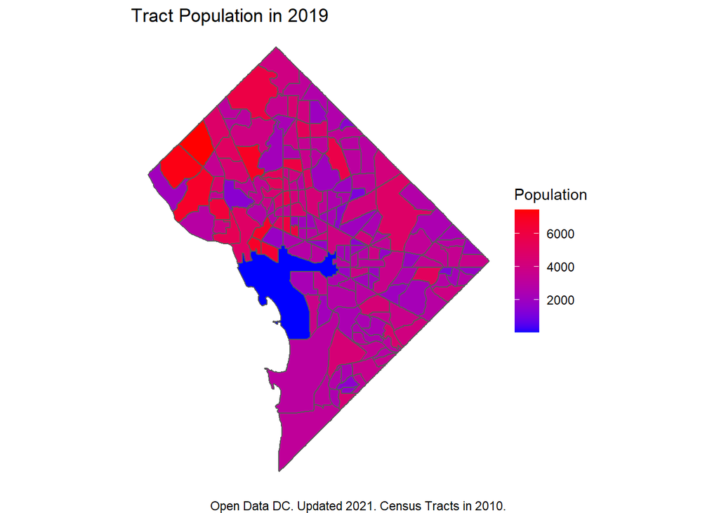

```r
pop_map
```

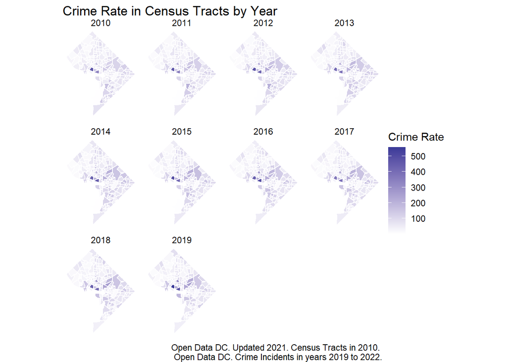

```r
crimerate_map
```

The map below visualizes crimes reported in DC in 2021 (light pink) and the location of police stations (blue). We can see that there are more police stations in high-crime reported areas. We also see that many crimes are concentrated on busy roads, namely Connecticut Ave, Wisconsin Ave, and Georgia Ave

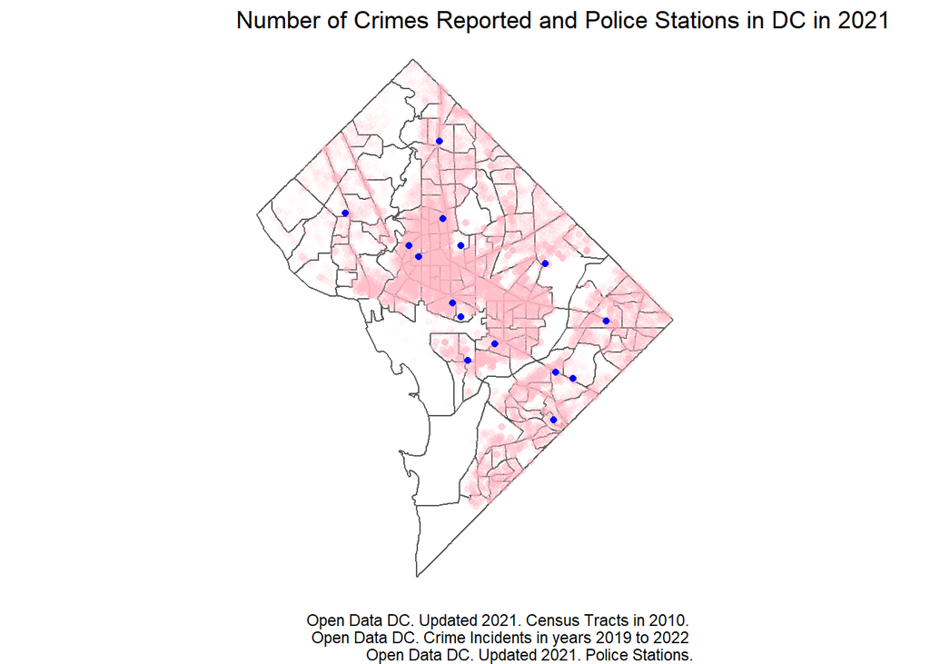

```r
crime_police21
```

Based the data visualizations above, crime decreased overall during the pandemic, which is most likely due to the pandemic shutdowns that took place in 2020 and the slow reopening/use of of shops, restaurants, workplaces, and transit in 2021 and 2022.